# Infrastructure for R peeps

Steph Locke (@SteffLocke)

2017-04-20

# Poll

http://dpll.co/17175e5

# Steph Locke

- Locke Data
- Presenter on Data Science, BI, and DataOps
- Microsoft Data Platform MVP
- User group leader: [MSFT Stack](http://www.meetup.com/MSFT%20Stack) & [CaRdiff](http://www.meetup.com/Cardiff-R-User-Group/)
- Conference organiser: [satRdays](http://planning.satrdays.org) & [Battle of the Beards](http://battleofthebeards.info)

github.com/StephLocke | itsalocke.com | [T: SteffLocke](https://twitter.com/stefflocke)

# Fundamentals

# Fundamentals

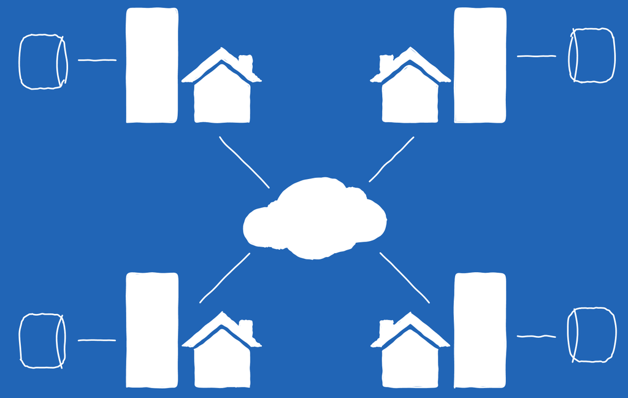

# Networks

- Access
  - Names
  - IPs
  - Device addresses
  - Ports
- Restricting access
  - Firewalls
- Safety
  - Encryption
  - Whitelisting

# Storage

- Access
  - Persistence
  - Users
  - Metadata
- Restricting access
  - Permissions
- Safety
  - Role Based Access
  - Redundancy
  - Backups

# OS

- Access
  - Authentication systems
- Restricting access
  - Permissions
- Safety
  - User hygiene
  - Patching

# PowerShell

The language for working with all things Microsoft these days.

- Also [works on Linux](http://www.howtogeek.com/267858/how-to-install-microsoft-powershell-on-linux-or-os-x/)

```powershell
Get-ChildItem |
  Where Name -notlike "*.tar.gz" |
    Export-Csv "filelist.csv"

Import-Csv "filelist.csv"
```

# Bash

The continued language of Linux

- Also [works on Windows (10)](http://www.howtogeek.com/249966/how-to-install-and-use-the-linux-bash-shell-on-windows-10/)

```bash
find . -maxdepth 1 ! -name '*.tar.gz' |
  sed 's/[ \t]/,/g' > filelist.csv

cat filelist.csv
```

# Call command line from R

Interactions are available from `base` package

```r
?system  # not recommended
?system2 # works better with Windows too
?shell   # the lower level call
```

# Windows / Linux file differences

- Windows
- Case insensitive
- Permissions inherit from parent object by default
- Linux
- Case sensitive
- Permisions inherit from user or one of other many overriding ways

# Windows OS Variants

- Windows 10 - not a server
- Windows server YYYY - GUI
- Windows Nano - Headless

# Docker

# Docker

- Contained code
- Scripted infrastructure
- Bundled dependencies
- Lower maintenance than VMs

# Why use it?

- Scripted installs
- Saved from “Next, Next, Next”
- Insanely disposable
- Control your ops
- Rapidly developing

# Why not use it?

- Insanely disposable
- Control your ops
- Rapidly developing

# Why not use it? Versions

# How to use it (locally)

- Install it
- Run the Docker Quickstart Terminal

```
docker run -it ubuntu /bin/bash
```

# How to use it - demo

[video not shown]

# Docker-Machine

[docker-machine](https://docs.docker.com/machine/overview/) is needed to run containers, work on remote machines hosting docker containers, and to work with swarm clusters

# Docker plugins

[Plugins](https://docs.docker.com/engine/extend/legacy_plugins/) allow you to extend docker capabilities. Most plugins are network and file system related.

# Follow on

- [Why script infrastructure?](http://www.cio.com/article/3017722/infrastructure/what-is-infrastructure-as-code-and-why-should-you-embrace-it.html)
- [Get started with docker](https://docs.docker.com/windows/)

# Next steps

# Hard-won lessons

- Do work today so tomorrow’s work is new and interesting
- You’re only as good as your last restore
- Use the VMs & the cloud
- Never use `sa`
- Virus scanning + database files never mixes well

# Wrap up

- Questions during the break
- Get the slides: bit.ly/infRastructure
- Keep in touch: @SteffLocke

# Windows links

- [TechNet library](https://technet.microsoft.com/en-us/library/bb625087.aspx)
- [Microsoft Virtual Academy](https://mva.microsoft.com/product-training/windows-server#!jobf=IT%20Professional&lang=1033)
- [Windows networking lessons](http://www.howtogeek.com/school/windows-network-sharing/)

# Linux links

- [Linux Network Admin Guide](http://www.tldp.org/LDP/nag2/nag2.pdf)
- [Linux Survival](http://linuxsurvival.com/)
- [Linux Foundation free training materials](https://training.linuxfoundation.org/free-linux-training)

# Misc. links

- [12 factor app](https://12factor.net/)
- [bash.academy](http://www.bash.academy/)
- iptools
- [IT abbreviations](https://en.wikipedia.org/wiki/List_of_computing_and_IT_abbreviations)